# Final Project: Power vs Precision

2026-04-24

I am fasicinated by the game of golf and the constant persuit of finding ways to improve and lower my score. Power has become a popular topic in the world of golf with players hitting the ball farther every year but the precise skills like putting and chipping around the green also play a strong part in determining a players score. My goal with this project is evaluate which physiological skill set is more predictive of scoring performance on the PGA Tour.

### Background

Professional golf performance is measured using several key metrics:

- Driving Distance: average distance of tee shots (power)
- Driving Accuracy: percentage of fairways hit (control)
- Greens in Regulation (GIR): ability to reach the green efficiently
- Putting Average: efficiency on the green

These metrics represent different aspects of biomechanics and motor control. Understanding which of these best predicts scoring can provide insight into the biological demands of elite golf performance.

### Results

The following plots and models were generated using 2020 PGA tour data retrieved from an article written by Steve Russo called “PGA TOUR STATS - 2020 SEASON Stats for the PGA Tour 2020 Season”.

#### Power vs Scoring

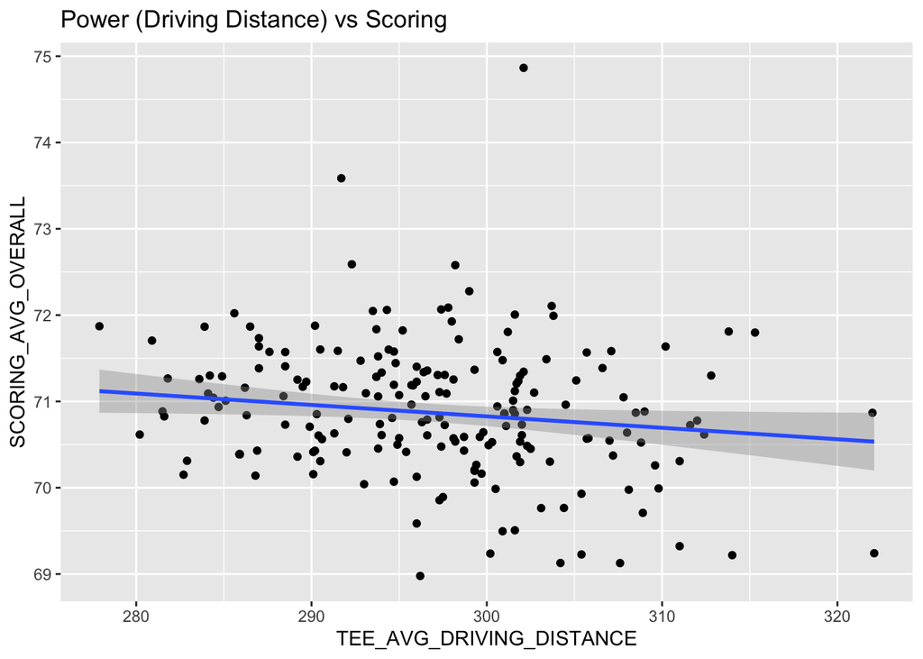

The relationship between driving distance and scoring average appears relatively weak, with only a slight trend toward improved scoring at greater distances. While longer drives may provide advantageous positioning, the variability suggests that power alone is not a strong predictor of performance.

#### Precision (GIR) vs Scoring

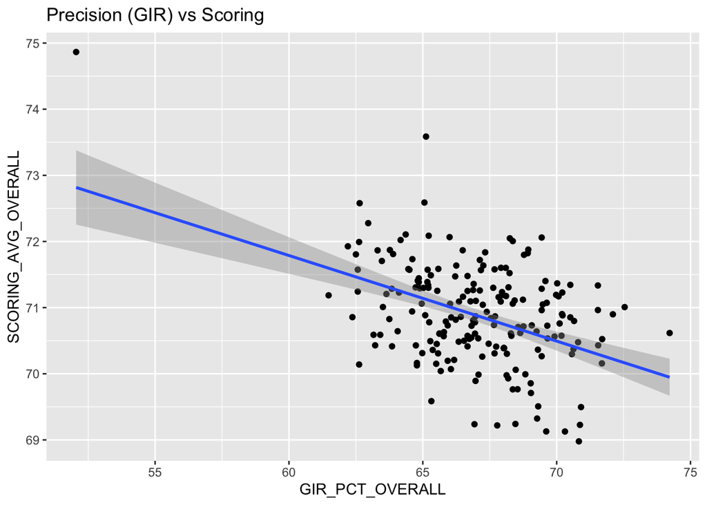

Greens in Regulation (GIR) shows a stronger negative relationship with scoring average, indicating that players who consistently reach the green in fewer strokes tend to achieve lower scores. This highlights the importance of precision in approach shots.

#### Putting Performance vs Scoring

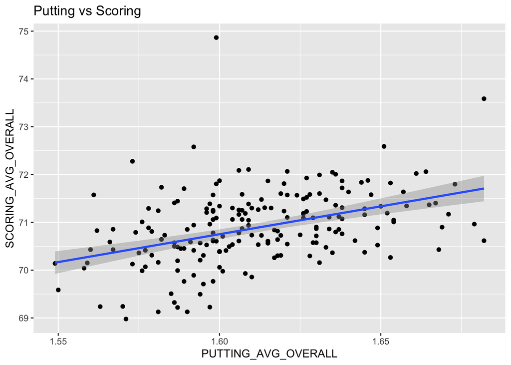

Putting performance demonstrates a clear relationship with scoring, where more efficient putting is associated with lower scoring averages. This suggests that fine motor control and consistency on the green are critical components of success.

### Statistical Analysis

```
##
## Call:
## lm(formula = SCORING_AVG_OVERALL ~ TEE_AVG_DRIVING_DISTANCE +
##     TEE_AVG_CLUB_HEAD_SPEED + TEE_DRIVING_ACCURACY_PCT + GIR_PCT_OVERALL +
##     PUTTING_AVG_OVERALL, data = golf_clean)
##
## Residuals:
##      Min       1Q   Median       3Q      Max
## -1.15156 -0.21339 -0.01359  0.23534  1.12216
##
## Coefficients:
##                           Estimate Std. Error t value Pr(>|t|)
## (Intercept)              57.493329   1.992588  28.854  < 2e-16 ***
## TEE_AVG_DRIVING_DISTANCE -0.020787   0.006423  -3.236  0.00141 **
## TEE_AVG_CLUB_HEAD_SPEED  -0.010279   0.013099  -0.785  0.43354
## TEE_DRIVING_ACCURACY_PCT -0.034510   0.007934  -4.349 2.16e-05 ***
## GIR_PCT_OVERALL          -0.219593   0.013783 -15.932  < 2e-16 ***
## PUTTING_AVG_OVERALL      23.301243   1.115111  20.896  < 2e-16 ***
## ---
## Signif. codes:  0 '***' 0.001 '**' 0.01 '*' 0.05 '.' 0.1 ' ' 1
##
## Residual standard error: 0.38 on 202 degrees of freedom
## Multiple R-squared:  0.7598, Adjusted R-squared:  0.7538
## F-statistic: 127.8 on 5 and 202 DF,  p-value: < 2.2e-16
```

### Pricipal Component Analysis

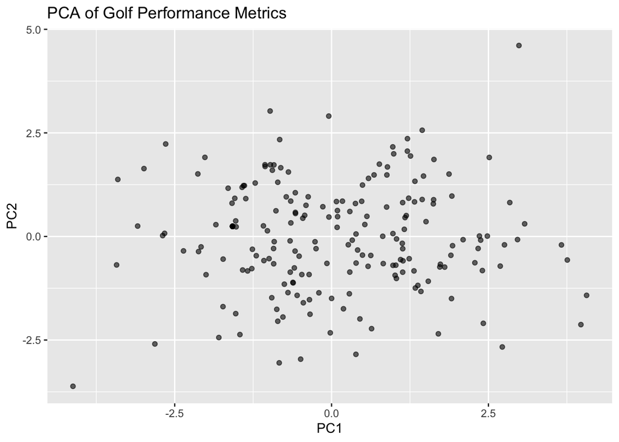

Principal Component Analysis (PCA) was used to reduce multiple performance variables into a smaller number of underlying components. The first principal component (PC1) represents the largest source of variation and likely reflects overall performance or precision-based traits. The second component (PC2) may separate power-based variables from precision-based variables.

### Conclusion

Overall, this analysis indicates that precision-based skills are stronger predictors of scoring performance than power-based metrics. From a biological perspective, this supports the idea that fine motor control and coordination play a greater role than maximal force production in determining success in professional golf.